**Deep Learning for Mechanical Engineering**  
**CNN**

Instructor: Prof. Seungchul Lee  
http://iai.postech.ac.kr/  
Industrial AI Lab at POSTECH

# Problem 1

(1) [1pt] Explain the difference between cross correlation and convolution in 1D.

(2) [1pt] (T/F) CNN cannot reduce output size without pooling layer.

(3) [1pt] (T/F) max pooling allows a neuron in a network to have information about features in a larger part of the image, compared to a neuron at the same depth in a network without max pooling.

(4) [1pt] Can you implement average pooling as a special case of a convolution layer? If so, do it.

(5) [1pt] Can you implement max pooling as a special case of a convolution layer? If so, do it.

# Problem 2: Sign Language Classification with CNN

As we studied in the lecture, CNN can classify images directly. So, the only thing we need to apply CNN is the picture of an object. This advantage allows CNN to be applied to various industries. In this problem, we are going to classify sign language by CNN. Then you will able to directly conversate with disabled people even if you don't know sign language.

Download data

- [sign_language_train_img.npy](https://www.dropbox.com/s/i82yzhluxw38dxy/sign_language_train_img.npy?dl=1)
- [sign_language_train_label.npy](https://www.dropbox.com/s/v1orq1u00zmi7sc/sign_language_train_label.npy?dl=1)
- [sign_language_test_img.npy](https://www.dropbox.com/s/gemue4tqyroecjz/sign_language_test_img.npy?dl=1)
- [sign_language_test_label.npy](https://www.dropbox.com/s/57dwhslzpdu6wwo/sign_language_test_label.npy?dl=1)

```python
import tensorflow as tf
import os
import cv2
import numpy as np
from six.moves import cPickle
import matplotlib.pyplot as plt
%matplotlib inline
from silence_tensorflow import silence_tensorflow
```

(1) Load and plot 6 random data.

You need to load total 4 files.

- sign_language_train_img.npy
- sign_language_train_label.npy
- sign_language_test_img.npy
- sign_language_test_label.npy

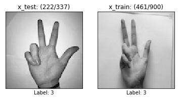

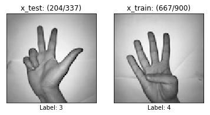

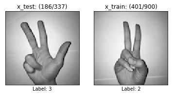

```python
## Your code here
#
```

(2) Design your training and test dataset.

Note: you should check data shape. (CNN input is image!)

```python
## Your code here
#
```

```
train_x:  (900, 100, 100, 1)
train_y:  (900, 6)
test_x:  (337, 100, 100, 1)
test_x:  (337, 6)
```

(3) Design your CNN structure and train your model.

- input
- filter size
- pooling size
- hidden layer
- output

```python
## Your code here
#
```

```
<keras.callbacks.History at 0x7f8fcd524c18>
```

(4) Test your model. Calculate accuracy and plot random image with its predicted and true label.

Note: test accuracy should be higher than 80%.

```python
## Your code here
#
```

```
loss = 0.48612237, Accuracy = 91 %
```

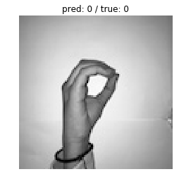

```python
## Your code here
#
```

# Problem 3

For your next vacation, you decided to spend a week with five of your friends from school. It is a very convenient house with many things to do nearby. But the most important benefit is that everybody has commited to be happy when they are in the house. So anyone wanting to enter the house must prove their current state of happiness.

As a deep learning expert, to make sure the "Happy" rule is strictly applied, you are going to build an algorithm which that uses pictures from the front door camera to check if the person is happy or not. The door should open only if the person is happy.

You have gathered pictures of your friends and yourself, taken by the front-door camera. The dataset is labbeled.

Download Happy house data from :

- [expression_train_img](https://www.dropbox.com/s/xk5vce4tjeu1xgp/expression_train_img.npy?dl=1)
- [expression_train_label](https://www.dropbox.com/s/8rfezgm8jsce1bl/expression_train_label.npy?dl=1)
- [expression_test_img](https://www.dropbox.com/s/mixsror4s2q7i16/expression_test_img.npy?dl=1)
- [expression_test_label](https://www.dropbox.com/s/2ra9q5c2qe2xgix/expression_test_label.npy?dl=1)
- [expression_happy_img](https://www.dropbox.com/s/lbanhy0okrpm1pi/expression_happy_img.npy?dl=1)
- [expression_happy_label](https://www.dropbox.com/s/k91fjccy9hthra3/expression_happy_label.npy?dl=1)
- [expression_unpappy_img](https://www.dropbox.com/s/a0oggm69d5u7w05/expression_unhappy_img.npy?dl=1)
- [expression_unhappy_label](https://www.dropbox.com/s/ucza3wm2kmooowv/expression_unhappy_label.npy?dl=1)

1) It is now time to solve the "Happy" Challenge. Train your CNN model.

```python
## Your code here
#
```

2) Test/evaluate your model

```python
## Your code here
#
```

3) Test with your own image. Take pictures of your friends and yourself.

```python
## Your code here
#
```

# Problem 4: Understanding the Feature Map for Each Layer

Let's build a CNN model that classifies steel surface defects.

- In order for CNN to preceed with classification, training was carried out using a convolution filter.
- Let's visualize the feature map for each convolutional layer to understand the CNN's decision boundary.
- [NEU](http://faculty.neu.edu.cn/yunhyan/NEU_surface_defect_database.html) steel surface defects example.
- To classify defects images into 6 classes.

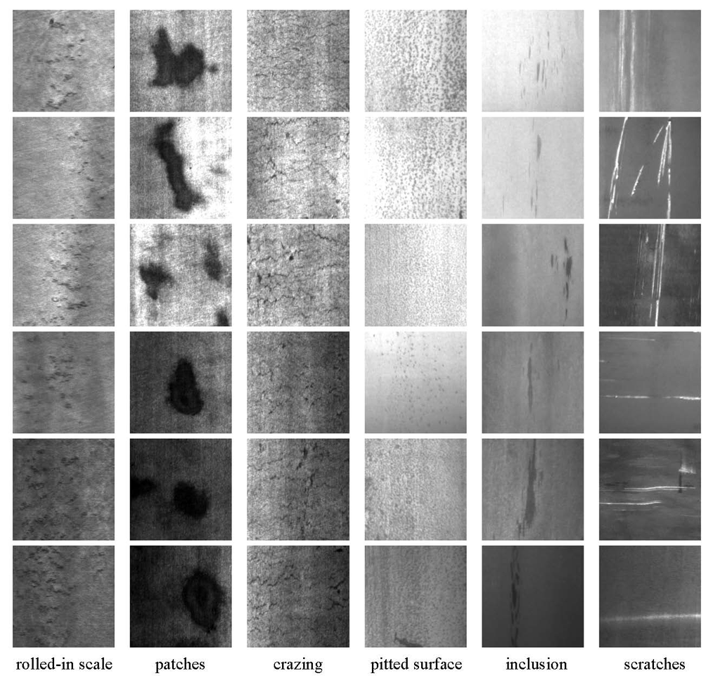

Download NEU steel surface defects images and labels

- [NEU train images](https://www.dropbox.com/s/vqbn1r96yjrchtq/NEU_train_imgs.npy?dl=1)
- [NEU train labels](https://www.dropbox.com/s/rcxgoipeip536fl/NEU_train_labels.npy?dl=1)
- [NEU test images](https://www.dropbox.com/s/dxaswt9l05pup8i/NEU_test_imgs.npy?dl=1)
- [NEU test labels](https://www.dropbox.com/s/329vil0anumk7d1/NEU_test_labels.npy?dl=1)

(1) Load and plot 3 random data for 6 classes.

You need to load total 4 files.

- NEU_train_imgs.npy
- NEU_train_labels.npy
- NEU_test_imgs.npy
- NEU_test_labels.npy

```python
## Your code here
#
```

```
The number of training images : 1500, shape : (1500, 200, 200, 1)
The number of training labels: 1500, shape : (1500,)
The number of testing images : 300, shape : (300, 200, 200, 1)
The number of testing labels: 300, shape : (300,)
```

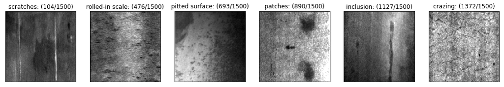

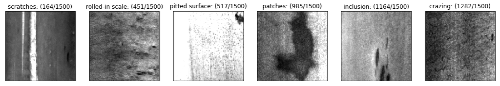

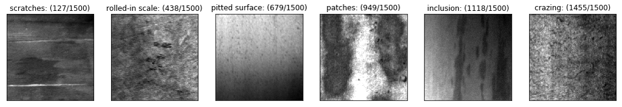

```python
## Your code here
#
```

(2) Design your CNN structure.

Note:

- Check data shape. (CNN input is image!)
- Construct 5-convolution block (conv_layer - pool_layer)

```python
model.summary()
```

```
Model: "sequential"
_________________________________________________________________
Layer (type)                 Output Shape              Param #
=================================================================
conv2d (Conv2D)              (None, 200, 200, 32)      320
_________________________________________________________________
max_pooling2d (MaxPooling2D) (None, 100, 100, 32)      0
_________________________________________________________________
conv2d_1 (Conv2D)            (None, 100, 100, 64)      18496
_________________________________________________________________
max_pooling2d_1 (MaxPooling2 (None, 50, 50, 64)        0
_________________________________________________________________
conv2d_2 (Conv2D)            (None, 50, 50, 128)       73856
_________________________________________________________________
max_pooling2d_2 (MaxPooling2 (None, 25, 25, 128)       0
_________________________________________________________________
conv2d_3 (Conv2D)            (None, 25, 25, 256)       295168
_________________________________________________________________
max_pooling2d_3 (MaxPooling2 (None, 12, 12, 256)       0
_________________________________________________________________
conv2d_4 (Conv2D)            (None, 12, 12, 512)       1180160
_________________________________________________________________
max_pooling2d_4 (MaxPooling2 (None, 6, 6, 512)         0
_________________________________________________________________
flatten (Flatten)            (None, 18432)             0
_________________________________________________________________
dense (Dense)                (None, 128)               2359424
_________________________________________________________________
dense_1 (Dense)              (None, 6)                 774
=================================================================
Total params: 3,928,198
Trainable params: 3,928,198
Non-trainable params: 0
_________________________________________________________________
```

```python
## Your code here
#
```

```
<keras.callbacks.History at 0x7f8fd3f70be0>
```

(4) Test your model. Calculate accuracy and plot random image with its predicted and true label.

Note: test accuracy should be higher than 90%.

```python
## Your code here
#
```

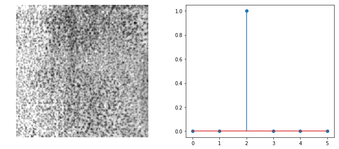

```
Prediction : pitted surface
True Label : pitted surface
```

```python
## Your code here
#
```

(5) Visualize the feature maps (output) for the convolutional layers from 1 to 5.

- Visualize the output using the first data from the test dataset.
- Visualize up to 6 channels on each layer.

```python
## Your code here

outputs
```

```
[<KerasTensor: shape=(None, 200, 200, 32) dtype=float32 (created by layer 'conv2d')>,
 <KerasTensor: shape=(None, 100, 100, 32) dtype=float32 (created by layer 'max_pooling2d')>,
 <KerasTensor: shape=(None, 100, 100, 64) dtype=float32 (created by layer 'conv2d_1')>,
 <KerasTensor: shape=(None, 50, 50, 64) dtype=float32 (created by layer 'max_pooling2d_1')>,
 <KerasTensor: shape=(None, 50, 50, 128) dtype=float32 (created by layer 'conv2d_2')>,
 <KerasTensor: shape=(None, 25, 25, 128) dtype=float32 (created by layer 'max_pooling2d_2')>,
 <KerasTensor: shape=(None, 25, 25, 256) dtype=float32 (created by layer 'conv2d_3')>,
 <KerasTensor: shape=(None, 12, 12, 256) dtype=float32 (created by layer 'max_pooling2d_3')>,
 <KerasTensor: shape=(None, 12, 12, 512) dtype=float32 (created by layer 'conv2d_4')>,
 <KerasTensor: shape=(None, 6, 6, 512) dtype=float32 (created by layer 'max_pooling2d_4')>,
 <KerasTensor: shape=(None, 18432) dtype=float32 (created by layer 'flatten')>,
 <KerasTensor: shape=(None, 128) dtype=float32 (created by layer 'dense')>,
 <KerasTensor: shape=(None, 6) dtype=float32 (created by layer 'dense_1')>]
```

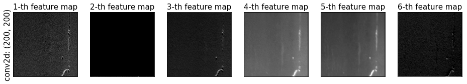

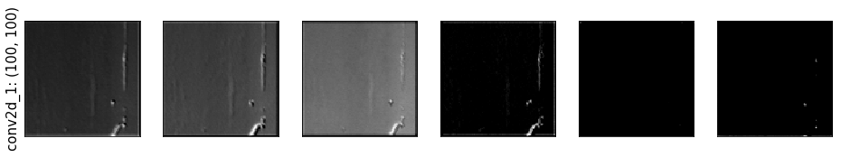

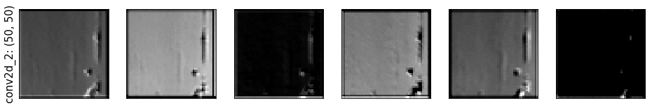

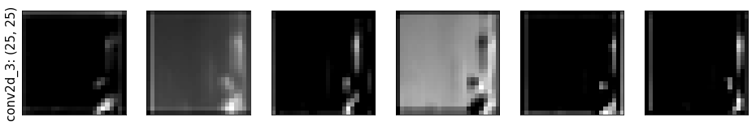

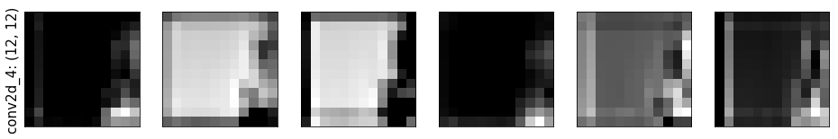

```python
## Your code here
#
```